**Dragos Ailoae**

# Intro to Machine Learning

# Tree-Based Methods

The relatively recent explosion in available computing power allows for old methods to be reborn as well as new methods to be created. One such machine learning algorithm that is directly the product of the computer age is the random forest, a computationally extensive prediction algorithm based on bootstrapped decision trees which possesses impressive predictive capability.

### Application - Athletes Salary Prediction

*Hitters* is a data set that contains 20 statistics on 322 Major League Baseball players from the 1986 and 1987 seasons. We will attempt to predict a player's Salary, or rather log(Salary), based on the number of years in the major leagues and the number of hits. The variables of interest are:

- **Salary = salary on opening day 1987 (thousands of dollars)**
- Years = Number of years in the major league
- Hits = Number of hits in 1986

Let's begin by loading some necessary packages...

```r
rm(list=ls())    # Removes all items in Environment!
#
# OPTIONS:
options(warn=-1) # Suppress warnings
#
# LOAD PACKAGES:
packages <- c("IRdisplay","tidyverse","modelsummary","ISLR","rpart","rpart.plot","randomForest")
# Loop though vector and load respective packages with options:
# zzz <- lapply(packages, require, character.only = TRUE) # verbose
zzz <- lapply(packages, function(xxx) suppressMessages(require(xxx,
               character.only = TRUE, quietly=TRUE, warn.conflicts = FALSE)))
```

... and taking a peak at the dataset:

```r
data(Hitters)
my.df <- data.frame(Hitters)  %>% drop_na()   # filter out N/As
my.df$LogSalary <- log(my.df$Salary)

datasummary_skim(my.df, output = "jupyter")
head(my.df)
```

Unique (#)

Missing (%)

Mean

SD

Min

Median

Max

AtBat

209

0

403.6

147.3

19.0

413.0

687.0

[figure not shown]

Hits

130

0

107.8

45.1

1.0

103.0

238.0

HmRun

35

0

11.6

8.8

0.0

9.0

40.0

Runs

92

0

54.7

25.5

0.0

52.0

130.0

RBI

94

0

51.5

25.9

0.0

47.0

121.0

Walks

87

0

41.1

21.7

0.0

37.0

105.0

Years

21

0

7.3

4.8

1.0

6.0

24.0

CAtBat

257

0

2657.5

2286.6

19.0

1931.0

14053.0

CHits

241

0

722.2

648.2

4.0

516.0

4256.0

CHmRun

129

0

69.2

82.2

0.0

40.0

548.0

CRuns

226

0

361.2

331.2

2.0

250.0

2165.0

CRBI

226

0

330.4

323.4

3.0

230.0

1659.0

CWalks

207

0

260.3

264.1

1.0

174.0

1566.0

PutOuts

199

0

290.7

279.9

0.0

224.0

1377.0

[figure not shown]

Assists

145

0

118.8

145.1

0.0

45.0

492.0

Errors

29

0

8.6

6.6

0.0

7.0

32.0

Salary

150

0

535.9

451.1

67.5

425.0

2460.0

LogSalary

150

0

5.9

0.9

4.2

6.1

7.8

A data.frame: 6 × 21

|  | AtBat <int> | Hits <int> | HmRun <int> | Runs <int> | RBI <int> | Walks <int> | Years <int> | CAtBat <int> | CHits <int> | CHmRun <int> | ... | CRBI <int> | CWalks <int> | League <fct> | Division <fct> | PutOuts <int> | Assists <int> | Errors <int> | Salary <dbl> | NewLeague <fct> | LogSalary <dbl> |
| --- | --- | --- | --- | --- | --- | --- | --- | --- | --- | --- | --- | --- | --- | --- | --- | --- | --- | --- | --- | --- | --- |
| -Alan Ashby | 315 | 81 | 7 | 24 | 38 | 39 | 14 | 3449 | 835 | 69 | ... | 414 | 375 | N | W | 632 | 43 | 10 | 475.0 | N | 6.163315 |
| -Alvin Davis | 479 | 130 | 18 | 66 | 72 | 76 | 3 | 1624 | 457 | 63 | ... | 266 | 263 | A | W | 880 | 82 | 14 | 480.0 | A | 6.173786 |
| -Andre Dawson | 496 | 141 | 20 | 65 | 78 | 37 | 11 | 5628 | 1575 | 225 | ... | 838 | 354 | N | E | 200 | 11 | 3 | 500.0 | N | 6.214608 |
| -Andres Galarraga | 321 | 87 | 10 | 39 | 42 | 30 | 2 | 396 | 101 | 12 | ... | 46 | 33 | N | E | 805 | 40 | 4 | 91.5 | N | 4.516339 |
| -Alfredo Griffin | 594 | 169 | 4 | 74 | 51 | 35 | 11 | 4408 | 1133 | 19 | ... | 336 | 194 | A | W | 282 | 421 | 25 | 750.0 | A | 6.620073 |
| -Al Newman | 185 | 37 | 1 | 23 | 8 | 21 | 2 | 214 | 42 | 1 | ... | 9 | 24 | N | E | 76 | 127 | 7 | 70.0 | A | 4.248495 |

### Dataset Split: Train-Validation-Test

Train-Valid-Test split is a technique to evaluate the performance of your machine learning model — classification or regression alike. You take a given dataset and divide it into three subsets:

#### Train Dataset

- Set of data used for learning (by the model), that is, to fit the parameters to the machine learning model

#### Validation Dataset

- Set of data used to provide an unbiased evaluation of a model fitted on the training dataset while tuning model hyperparameters.
- Also play a role in other forms of model preparation, such as feature selection, threshold cut-off selection.

#### Test Dataset

- Set of data used to provide an unbiased evaluation of a final model fitted on the training dataset. Basically, we do not touch this dataset until the final evaluation.

Since our model has few hyper-parameters which will be easy to validate and tune, we will ignore the validation split and just split our dataset 70/30 into a train and test subset.

```r
set.seed(200)   # set seed for sample replication

sample.id.train <- sample(1:nrow(my.df), 0.7 * nrow(my.df))
my.df.train <- my.df[sample.id.train,]
str(my.df.train)
```

```
'data.frame':	184 obs. of  21 variables:
 $ AtBat    : int  442 559 281 382 512 313 547 513 329 441 ...
 $ Hits     : int  131 141 76 101 117 78 137 137 83 128 ...
 $ HmRun    : int  18 2 3 16 29 6 2 20 9 16 ...
 $ Runs     : int  68 48 42 50 54 32 58 90 50 70 ...
 $ RBI      : int  77 61 25 55 88 41 47 95 39 73 ...
 $ Walks    : int  33 73 20 22 43 12 12 90 56 80 ...
 $ Years    : int  6 8 8 1 6 12 2 14 9 14 ...
 $ CAtBat   : int  1416 3162 2658 382 1750 3742 1038 5201 3828 6675 ...
 $ CHits    : int  398 874 657 101 412 968 271 1382 948 2095 ...
 $ CHmRun   : int  47 16 48 16 100 35 3 166 145 209 ...
 $ CRuns    : int  210 421 324 50 204 409 129 763 575 1072 ...
 $ CRBI     : int  203 349 300 55 276 321 80 734 528 1050 ...
 $ CWalks   : int  136 359 179 22 155 170 24 784 635 695 ...
 $ League   : Factor w/ 2 levels "A","N": 1 2 1 1 1 2 1 1 1 1 ...
 $ Division : Factor w/ 2 levels "E","W": 1 1 1 2 2 2 2 2 2 2 ...
 $ PutOuts  : int  233 352 106 200 1236 106 261 267 276 97 ...
 $ Assists  : int  7 414 144 7 98 206 459 5 6 218 ...
 $ Errors   : int  7 9 7 6 18 7 22 3 2 16 ...
 $ Salary   : num  550 925 341.7 97.5 100 ...
 $ NewLeague: Factor w/ 2 levels "A","N": 1 2 1 1 1 2 1 1 1 1 ...
 $ LogSalary: num  6.31 6.83 5.83 4.58 4.61 ...
```

```r
my.df.test <- my.df[ - sample.id.train,]
str(my.df.test)
```

```
'data.frame':	79 obs. of  21 variables:
 $ AtBat    : int  321 185 202 196 426 629 583 181 217 254 ...
 $ Hits     : int  87 37 53 43 109 168 168 41 46 68 ...
 $ HmRun    : int  10 1 4 7 3 18 17 1 7 2 ...
 $ Runs     : int  39 23 31 29 55 73 83 15 32 28 ...
 $ RBI      : int  42 8 26 27 43 102 80 21 19 26 ...
 $ Walks    : int  30 21 27 30 62 40 56 33 9 22 ...
 $ Years    : int  2 2 9 13 1 18 5 2 4 6 ...
 $ CAtBat   : int  396 214 1876 3231 426 8424 1646 232 694 999 ...
 $ CHits    : int  101 42 467 825 109 2464 452 50 160 236 ...
 $ CHmRun   : int  12 1 15 36 3 164 44 4 32 21 ...
 $ CRuns    : int  48 30 192 376 55 1008 219 20 86 108 ...
 $ CRBI     : int  46 9 186 290 43 1072 208 29 76 117 ...
 $ CWalks   : int  33 24 161 238 62 402 136 45 32 118 ...
 $ League   : Factor w/ 2 levels "A","N": 2 2 2 2 1 1 1 1 1 1 ...
 $ Division : Factor w/ 2 levels "E","W": 1 1 2 1 2 1 1 1 1 1 ...
 $ PutOuts  : int  805 76 304 80 361 1067 109 326 307 359 ...
 $ Assists  : int  40 127 45 45 22 157 292 29 25 30 ...
 $ Errors   : int  4 7 11 8 2 14 25 5 1 4 ...
 $ Salary   : num  91.5 70 512.5 240 115 ...
 $ NewLeague: Factor w/ 2 levels "A","N": 2 1 2 2 2 1 1 1 1 1 ...
 $ LogSalary: num  4.52 4.25 6.24 5.48 4.74 ...
```

### Decision Trees

Random Forests and Boosting/Bagging are techniques derived from the decision tree, which segments the feature space of a data set by minimizing the total variance at each step. The figure below illustrates the concept. Here x1 and x2 are two features which allow us to make predictions for a binary target variable y.

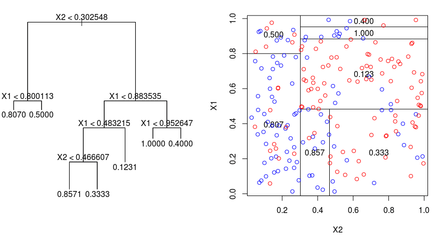

In R, the *rpart()* function from the rpart package fits a simple decision tree:

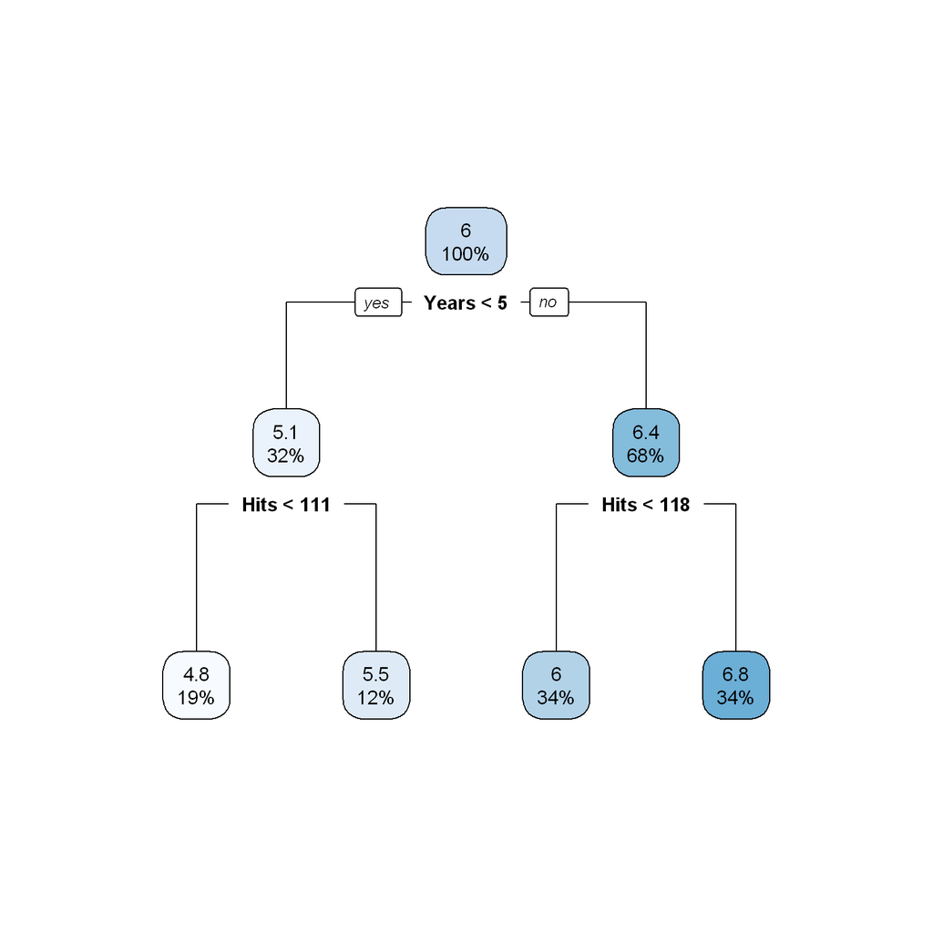

```r
options(repr.plot.width = 8, repr.plot.height = 8,repr.plot.res = 200)
my.tree.fit <- rpart(LogSalary ~ Years + Hits, data = my.df.train,
                 method = "anova", control = rpart.control(maxdepth = 2))
rpart.plot(my.tree.fit)
```

Note the ease of interpretation. If we want to predict the log salary of a new hitter who had been in the league for 6 seasons and had 110 hits the previous season, we would start at the top of the tree and compare 6 years to 5 years. Seeing that 6 is greater than five, we choose the right branch. Reaching the next split, we see that 110 hits is less than 118 and choose the left branch at this split, arriving at our log salary estimate of 6 for our new player (which corresponds to a salary point estimate of $403,428.79).

But if we want the best prediction, how could we know beforehand how many levels to include? By default, rpart will cross-validate the results of the tree and trim the tree to remove leaves that do not improve the model compared to the complexity it adds (this is called pruning).

Below we re-fit the model without controlling the depth and examine the results:

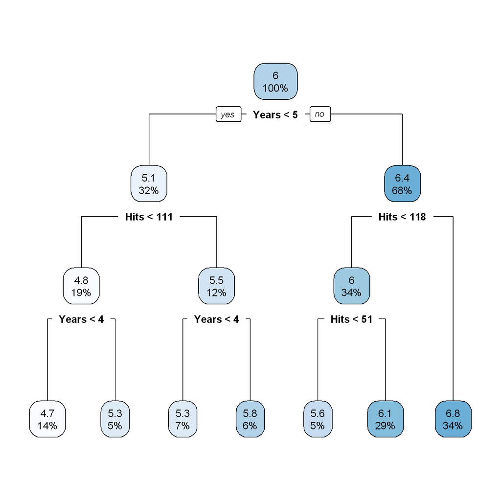

```r
# fit decision tree without controlling depth
my.tree.fit <- rpart(LogSalary ~ Years + Hits, data = my.df.train,
                 method = "anova")
# display results
rpart.plot(my.tree.fit)
```

Based on this new, cross-validated decision tree (optimal tree depth is 3) the estimate for the log salary of our new hitter becomes 6.1 ($445.857.77), and we can reasonably expect to have slightly more confidence in the accuracy of this point estimate. Each node in this visual display gives the estimate at each node as well as the percentage of training observations that are placed in that node.

We can use the predict function to estimate the log salary for every hitter in the testing set as well as calculate the mean squared error.

```r
my.tree.predict <- predict(my.tree.fit, my.df.test)  # NOTE we predict using the test dataset
round(head(my.tree.predict),3)
```

**-Andres Galarraga**

4.677

**-Al Newman**

4.677

**-Alex Trevino**

6.126

**-Bill Almon**

5.596

**-Bobby Bonilla**

4.677

**-Bill Buckner**

6.783

Compare this with the actual values:

```r
head(my.df.test)
```

A data.frame: 6 × 21

|  | AtBat <int> | Hits <int> | HmRun <int> | Runs <int> | RBI <int> | Walks <int> | Years <int> | CAtBat <int> | CHits <int> | CHmRun <int> | ... | CRBI <int> | CWalks <int> | League <fct> | Division <fct> | PutOuts <int> | Assists <int> | Errors <int> | Salary <dbl> | NewLeague <fct> | LogSalary <dbl> |
| --- | --- | --- | --- | --- | --- | --- | --- | --- | --- | --- | --- | --- | --- | --- | --- | --- | --- | --- | --- | --- | --- |
| -Andres Galarraga | 321 | 87 | 10 | 39 | 42 | 30 | 2 | 396 | 101 | 12 | ... | 46 | 33 | N | E | 805 | 40 | 4 | 91.500 | N | 4.516339 |
| -Al Newman | 185 | 37 | 1 | 23 | 8 | 21 | 2 | 214 | 42 | 1 | ... | 9 | 24 | N | E | 76 | 127 | 7 | 70.000 | A | 4.248495 |
| -Alex Trevino | 202 | 53 | 4 | 31 | 26 | 27 | 9 | 1876 | 467 | 15 | ... | 186 | 161 | N | W | 304 | 45 | 11 | 512.500 | N | 6.239301 |
| -Bill Almon | 196 | 43 | 7 | 29 | 27 | 30 | 13 | 3231 | 825 | 36 | ... | 290 | 238 | N | E | 80 | 45 | 8 | 240.000 | N | 5.480639 |
| -Bobby Bonilla | 426 | 109 | 3 | 55 | 43 | 62 | 1 | 426 | 109 | 3 | ... | 43 | 62 | A | W | 361 | 22 | 2 | 115.000 | N | 4.744932 |
| -Bill Buckner | 629 | 168 | 18 | 73 | 102 | 40 | 18 | 8424 | 2464 | 164 | ... | 1072 | 402 | A | E | 1067 | 157 | 14 | 776.667 | A | 6.655012 |

We can calculate the Mean Squared Error:

```r
MSE.tree <- mean((my.tree.predict - my.df.test$LogSalary)^2)
round(MSE.tree,3)
```

0.364

Compare this with the OLS predictions:

```r
my.OLS <- lm(LogSalary ~ Years + Hits, my.df.train)
my.OLS.predict <- predict(my.OLS, my.df.test)   # NOTE we predict using the test dataset
round(head(my.OLS.predict),3)
```

**-Andres Galarraga**

5.261

**-Al Newman**

4.78

**-Alex Trevino**

5.592

**-Bill Almon**

5.872

**-Bobby Bonilla**

5.379

**-Bill Buckner**

7.546

And the OLS Mean Squared Error of:

```r
MSE.OLS <- mean((my.OLS.predict - my.df.test$LogSalary)^2)
round(MSE.OLS,3)
```

0.461

So with this particular dataset the decision tree outperformed OLS.

### Random forests

Each tree grown has low bias and high variability (see [here](https://www.andreaperlato.com/theorypost/bias-variance-trade-off/) for more on the the bias-variance tradeoff). Therefore, in order to decrease the variability, we can calculate the average estimate over a large number of trees. By bootstrapping the data, we can generate a large number of trees and then average the prediction (for regression problems) or take a vote (for classification problems). This technique is called **bagging**, and can be performed with the *randomForest()* command from the randomForest package by setting the mtry argument equal to the number of predictors.

```r
my.bag <- randomForest(LogSalary ~ Years + Hits, data = my.df.train,
    mtry = 2, ntree = 5000)

my.bag.predict <- predict(my.bag, my.df.test)   # NOTE we predict using the test dataset
MSE.bag <- mean((my.bag.predict - my.df.test$LogSalary)^2)
round(MSE.bag,3)
```

0.313

The MSE is now 0.313 compared to 0.364 for the single decision tree.

### Learning More

To learn more I would start with the following resources listed in order of complexity:

- [An Introduction to Statistical Learning](https://www.statlearning.com/) | [Alternate link](https://static1.squarespace.com/static/5ff2adbe3fe4fe33db902812/t/6009dd9fa7bc363aa822d2c7/1611259312432/ISLR+Seventh+Printing.pdf)
- [The Elements of Statistical Learning](https://link.springer.com/book/10.1007/978-0-387-84858-7) | [Alternate link](https://www.sas.upenn.edu/~fdiebold/NoHesitations/BookAdvanced.pdf)
- [StatQuest videos](https://www.youtube.com/channel/UCtYLUTtgS3k1Fg4y5tAhLbw)

If you're interested in machine learning with Python, I highly recommend [Anaconda](https://www.anaconda.com/) with the [sklearn](https://scikit-learn.org/stable/) package.